# Risk Factor Analysis

## Outcome Variable

**Outcome Variable:** whz

## Predictor Variables

**Intervention Variable:** earlybf

**Adjustment Set:**

- arm
- sex
- W_mage
- meducyrs
- feducyrs
- hhwealth_quart
- hfoodsec
- W_mhtcm
- W_mwtkg
- W_mbmi
- vagbrth
- W_gagebrth
- W_birthwt
- W_birthlen
- W_nrooms
- W_nchldlt5
- brthmon
- W_parity
- impfloor
- impsan
- safeh20
- delta_W_mage
- delta_meducyrs
- delta_feducyrs
- delta_hhwealth_quart
- delta_hfoodsec
- delta_W_mhtcm
- delta_W_mwtkg
- delta_W_mbmi
- delta_vagbrth
- delta_W_gagebrth
- delta_W_birthwt
- delta_W_birthlen
- delta_W_nrooms
- delta_W_nchldlt5
- delta_brthmon
- delta_W_parity
- delta_impfloor
- delta_impsan
- delta_safeh20

## Stratifying Variables

The analysis was stratified on these variable(s):

- agecat
- studyid
- country

## Data Summary

| agecat | studyid | country | earlybf | n_cell | n |
| --- | --- | --- | --- | --- | --- |
| Birth | EE | PAKISTAN | 1 | 36 | 170 |
| Birth | EE | PAKISTAN | 0 | 134 | 170 |
| Birth | GMS-Nepal | NEPAL | 1 | 171 | 586 |
| Birth | GMS-Nepal | NEPAL | 0 | 415 | 586 |
| Birth | JiVitA-3 | BANGLADESH | 1 | 105 | 17943 |
| Birth | JiVitA-3 | BANGLADESH | 0 | 17838 | 17943 |
| Birth | JiVitA-4 | BANGLADESH | 1 | 1624 | 2396 |
| Birth | JiVitA-4 | BANGLADESH | 0 | 772 | 2396 |
| Birth | MAL-ED | BANGLADESH | 1 | 140 | 214 |
| Birth | MAL-ED | BANGLADESH | 0 | 74 | 214 |
| Birth | MAL-ED | BRAZIL | 1 | 26 | 62 |
| Birth | MAL-ED | BRAZIL | 0 | 36 | 62 |
| Birth | MAL-ED | INDIA | 1 | 31 | 44 |
| Birth | MAL-ED | INDIA | 0 | 13 | 44 |
| Birth | MAL-ED | NEPAL | 1 | 14 | 26 |
| Birth | MAL-ED | NEPAL | 0 | 12 | 26 |
| Birth | MAL-ED | PERU | 1 | 172 | 228 |
| Birth | MAL-ED | PERU | 0 | 56 | 228 |
| Birth | MAL-ED | SOUTH AFRICA | 1 | 69 | 110 |
| Birth | MAL-ED | SOUTH AFRICA | 0 | 41 | 110 |
| Birth | MAL-ED | TANZANIA, UNITED REPUBLIC OF | 1 | 103 | 115 |
| Birth | MAL-ED | TANZANIA, UNITED REPUBLIC OF | 0 | 12 | 115 |
| Birth | NIH-Crypto | BANGLADESH | 1 | 613 | 707 |
| Birth | NIH-Crypto | BANGLADESH | 0 | 94 | 707 |
| Birth | SAS-CompFeed | INDIA | 1 | 79 | 1072 |
| Birth | SAS-CompFeed | INDIA | 0 | 993 | 1072 |
| Birth | ZVITAMBO | ZIMBABWE | 1 | 6142 | 11514 |
| Birth | ZVITAMBO | ZIMBABWE | 0 | 5372 | 11514 |
| 6 months | EE | PAKISTAN | 1 | 69 | 364 |
| 6 months | EE | PAKISTAN | 0 | 295 | 364 |

[output cut: 52 more lines]

The following strata were considered:

- agecat: 24 months, studyid: EE, country: PAKISTAN
- agecat: 24 months, studyid: GMS-Nepal, country: NEPAL
- agecat: 24 months, studyid: JiVitA-3, country: BANGLADESH
- agecat: 24 months, studyid: JiVitA-4, country: BANGLADESH
- agecat: 24 months, studyid: MAL-ED, country: BANGLADESH
- agecat: 24 months, studyid: MAL-ED, country: BRAZIL
- agecat: 24 months, studyid: MAL-ED, country: INDIA
- agecat: 24 months, studyid: MAL-ED, country: NEPAL
- agecat: 24 months, studyid: MAL-ED, country: PERU
- agecat: 24 months, studyid: MAL-ED, country: SOUTH AFRICA
- agecat: 24 months, studyid: MAL-ED, country: TANZANIA, UNITED REPUBLIC OF
- agecat: 24 months, studyid: NIH-Crypto, country: BANGLADESH
- agecat: 24 months, studyid: ZVITAMBO, country: ZIMBABWE
- agecat: 6 months, studyid: EE, country: PAKISTAN
- agecat: 6 months, studyid: GMS-Nepal, country: NEPAL
- agecat: 6 months, studyid: JiVitA-3, country: BANGLADESH
- agecat: 6 months, studyid: JiVitA-4, country: BANGLADESH
- agecat: 6 months, studyid: MAL-ED, country: BANGLADESH
- agecat: 6 months, studyid: MAL-ED, country: BRAZIL
- agecat: 6 months, studyid: MAL-ED, country: INDIA
- agecat: 6 months, studyid: MAL-ED, country: NEPAL
- agecat: 6 months, studyid: MAL-ED, country: PERU
- agecat: 6 months, studyid: MAL-ED, country: SOUTH AFRICA
- agecat: 6 months, studyid: MAL-ED, country: TANZANIA, UNITED REPUBLIC OF
- agecat: 6 months, studyid: NIH-Crypto, country: BANGLADESH
- agecat: 6 months, studyid: SAS-CompFeed, country: INDIA
- agecat: 6 months, studyid: ZVITAMBO, country: ZIMBABWE
- agecat: Birth, studyid: EE, country: PAKISTAN
- agecat: Birth, studyid: GMS-Nepal, country: NEPAL
- agecat: Birth, studyid: JiVitA-3, country: BANGLADESH
- agecat: Birth, studyid: JiVitA-4, country: BANGLADESH
- agecat: Birth, studyid: MAL-ED, country: BANGLADESH
- agecat: Birth, studyid: MAL-ED, country: BRAZIL
- agecat: Birth, studyid: MAL-ED, country: INDIA
- agecat: Birth, studyid: MAL-ED, country: NEPAL
- agecat: Birth, studyid: MAL-ED, country: PERU
- agecat: Birth, studyid: MAL-ED, country: SOUTH AFRICA
- agecat: Birth, studyid: MAL-ED, country: TANZANIA, UNITED REPUBLIC OF
- agecat: Birth, studyid: NIH-Crypto, country: BANGLADESH
- agecat: Birth, studyid: SAS-CompFeed, country: INDIA
- agecat: Birth, studyid: ZVITAMBO, country: ZIMBABWE

### Dropped Strata

Some strata were dropped due to rare outcomes:

- agecat: 24 months, studyid: JiVitA-3, country: BANGLADESH

## Methods Detail

We’re interested in the causal parameters $E[Y_a]$ for all values of $a \in \mathcal{A}$. These parameters represent the mean outcome if, possibly contrary to fact, we intervened to set all units to have $A=a$. Under the randomization and positivity assumptions, these are identified by the statistical parameters $\psi_a=E_W[E_{Y|A,W}(Y|A=a,W)]$. In addition, we’re interested in the mean of $Y$, $E[Y]$ under no intervention (the observed mean). We will estimate these parameters by using SuperLearner to fit the relevant likelihood factors – $E_{Y|A,W}(Y|A=a,W)$ and $p(A=a|W)$, and then updating our likelihood fit using a joint TMLE.

For unadjusted analyses ($W=\{\}$), initial likelihoods were estimated using Lrnr_glm to estimate the simple $E(Y|A)$ and Lrnr_mean to estimate $p(A)$. For adjusted analyses, a small library containing Lrnr_glmnet, Lrnr_xgboost, and Lrnr_mean was used.

Having estimated these parameters, we will then use the delta method to estimate relative risks and attributable risks relative to a prespecified baseline level of $A$.

# Results Detail

## Results Plots

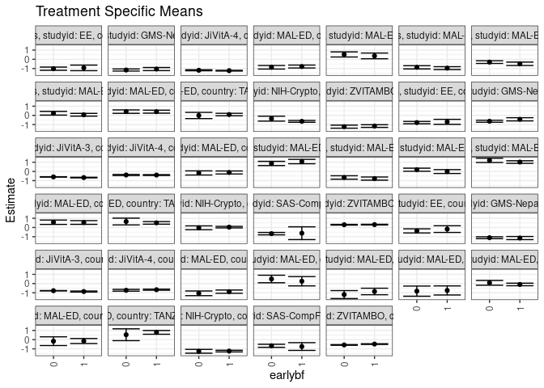

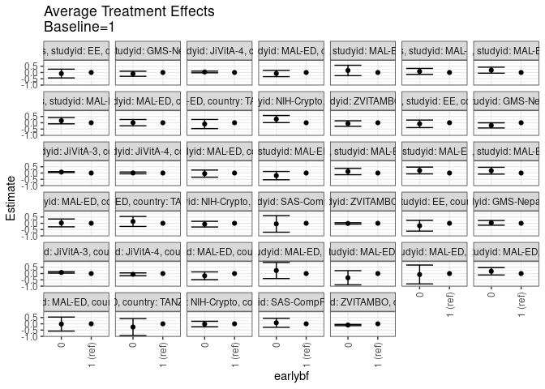

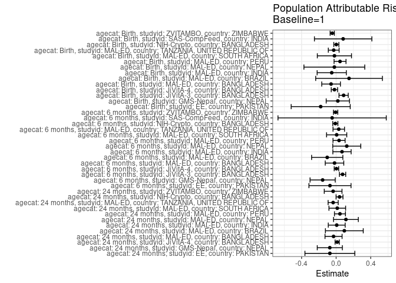

## Results Table

### Parameter: TSM

| agecat | studyid | country | intervention_level | baseline_level | estimate | ci_lower | ci_upper |
| --- | --- | --- | --- | --- | --- | --- | --- |
| Birth | EE | PAKISTAN | 1 | NA | -0.1734828 | -0.5373051 | 0.1903395 |
| Birth | EE | PAKISTAN | 0 | NA | -0.3671689 | -0.5885554 | -0.1457825 |
| Birth | GMS-Nepal | NEPAL | 1 | NA | -1.1456430 | -1.3156744 | -0.9756115 |
| Birth | GMS-Nepal | NEPAL | 0 | NA | -1.1096030 | -1.2132582 | -1.0059478 |
| Birth | JiVitA-3 | BANGLADESH | 1 | NA | -0.8644959 | -0.9155835 | -0.8134082 |
| Birth | JiVitA-3 | BANGLADESH | 0 | NA | -0.7774045 | -0.7968948 | -0.7579142 |
| Birth | JiVitA-4 | BANGLADESH | 1 | NA | -0.6687244 | -0.7285473 | -0.6089015 |
| Birth | JiVitA-4 | BANGLADESH | 0 | NA | -0.7303964 | -0.8289039 | -0.6318889 |
| Birth | MAL-ED | BANGLADESH | 1 | NA | -0.8804620 | -1.0585940 | -0.7023300 |
| Birth | MAL-ED | BANGLADESH | 0 | NA | -1.0601039 | -1.3128761 | -0.8073317 |
| Birth | MAL-ED | BRAZIL | 1 | NA | 0.2534827 | -0.2515747 | 0.7585401 |
| Birth | MAL-ED | BRAZIL | 0 | NA | 0.4971307 | 0.0888296 | 0.9054318 |
| Birth | MAL-ED | INDIA | 1 | NA | -0.8611906 | -1.2146759 | -0.5077054 |
| Birth | MAL-ED | INDIA | 0 | NA | -1.1963927 | -1.6302027 | -0.7625828 |
| Birth | MAL-ED | NEPAL | 1 | NA | -0.7476537 | -1.2417541 | -0.2535533 |
| Birth | MAL-ED | NEPAL | 0 | NA | -0.8235816 | -1.3753265 | -0.2718368 |
| Birth | MAL-ED | PERU | 1 | NA | -0.0971157 | -0.2364633 | 0.0422319 |
| Birth | MAL-ED | PERU | 0 | NA | 0.0823986 | -0.1758106 | 0.3406078 |
| Birth | MAL-ED | SOUTH AFRICA | 1 | NA | -0.1490775 | -0.4200388 | 0.1218837 |
| Birth | MAL-ED | SOUTH AFRICA | 0 | NA | -0.1696010 | -0.6433870 | 0.3041851 |
| Birth | MAL-ED | TANZANIA, UNITED REPUBLIC OF | 1 | NA | 0.7904899 | 0.5870970 | 0.9938828 |
| Birth | MAL-ED | TANZANIA, UNITED REPUBLIC OF | 0 | NA | 0.5312268 | -0.1114956 | 1.1739493 |
| Birth | NIH-Crypto | BANGLADESH | 1 | NA | -1.2464209 | -1.3358340 | -1.1570077 |
| Birth | NIH-Crypto | BANGLADESH | 0 | NA | -1.2661761 | -1.4730010 | -1.0593512 |
| Birth | SAS-CompFeed | INDIA | 1 | NA | -0.7487237 | -1.1696455 | -0.3278020 |
| Birth | SAS-CompFeed | INDIA | 0 | NA | -0.6673548 | -0.8346498 | -0.5000599 |
| Birth | ZVITAMBO | ZIMBABWE | 1 | NA | -0.4813377 | -0.5175617 | -0.4451137 |
| Birth | ZVITAMBO | ZIMBABWE | 0 | NA | -0.5774503 | -0.6156400 | -0.5392606 |
| 6 months | EE | PAKISTAN | 1 | NA | -0.7013076 | -0.9722404 | -0.4303748 |
| 6 months | EE | PAKISTAN | 0 | NA | -0.7870278 | -0.9148259 | -0.6592297 |
| 6 months | GMS-Nepal | NEPAL | 1 | NA | -0.4281611 | -0.6024181 | -0.2539041 |
| 6 months | GMS-Nepal | NEPAL | 0 | NA | -0.6382136 | -0.7459287 | -0.5304986 |
| 6 months | JiVitA-3 | BANGLADESH | 1 | NA | -0.6679202 | -0.6988730 | -0.6369675 |
| 6 months | JiVitA-3 | BANGLADESH | 0 | NA | -0.5933555 | -0.6133923 | -0.5733186 |
| 6 months | JiVitA-4 | BANGLADESH | 1 | NA | -0.3933501 | -0.4379016 | -0.3487986 |
| 6 months | JiVitA-4 | BANGLADESH | 0 | NA | -0.3866568 | -0.4485864 | -0.3247271 |
| 6 months | MAL-ED | BANGLADESH | 1 | NA | -0.1127777 | -0.2776539 | 0.0520986 |
| 6 months | MAL-ED | BANGLADESH | 0 | NA | -0.1613204 | -0.3864126 | 0.0637718 |
| 6 months | MAL-ED | BRAZIL | 1 | NA | 1.0752946 | 0.8385044 | 1.3120849 |
| 6 months | MAL-ED | BRAZIL | 0 | NA | 0.8688628 | 0.6397699 | 1.0979557 |
| 6 months | MAL-ED | INDIA | 1 | NA | -0.7757577 | -0.9478784 | -0.6036369 |
| 6 months | MAL-ED | INDIA | 0 | NA | -0.6552694 | -0.8416303 | -0.4689085 |
| 6 months | MAL-ED | NEPAL | 1 | NA | -0.0125478 | -0.2251118 | 0.2000161 |
| 6 months | MAL-ED | NEPAL | 0 | NA | 0.1875095 | 0.0215401 | 0.3534789 |
| 6 months | MAL-ED | PERU | 1 | NA | 1.0192411 | 0.8766600 | 1.1618222 |
| 6 months | MAL-ED | PERU | 0 | NA | 1.2035876 | 0.9728402 | 1.4343349 |
| 6 months | MAL-ED | SOUTH AFRICA | 1 | NA | 0.5439677 | 0.3431859 | 0.7447496 |
| 6 months | MAL-ED | SOUTH AFRICA | 0 | NA | 0.5717425 | 0.3338384 | 0.8096465 |
| 6 months | MAL-ED | TANZANIA, UNITED REPUBLIC OF | 1 | NA | 0.5058159 | 0.3640964 | 0.6475354 |
| 6 months | MAL-ED | TANZANIA, UNITED REPUBLIC OF | 0 | NA | 0.6501574 | 0.2824856 | 1.0178291 |
| 6 months | NIH-Crypto | BANGLADESH | 1 | NA | 0.0391312 | -0.0461854 | 0.1244478 |
| 6 months | NIH-Crypto | BANGLADESH | 0 | NA | -0.0316823 | -0.2406257 | 0.1772612 |
| 6 months | SAS-CompFeed | INDIA | 1 | NA | -0.6193063 | -1.3132515 | 0.0746389 |
| 6 months | SAS-CompFeed | INDIA | 0 | NA | -0.6679562 | -0.7976911 | -0.5382213 |
| 6 months | ZVITAMBO | ZIMBABWE | 1 | NA | 0.3135120 | 0.2768797 | 0.3501442 |
| 6 months | ZVITAMBO | ZIMBABWE | 0 | NA | 0.3013315 | 0.2604875 | 0.3421756 |
| 24 months | EE | PAKISTAN | 1 | NA | -0.9319369 | -1.2345936 | -0.6292802 |
| 24 months | EE | PAKISTAN | 0 | NA | -1.0188011 | -1.1922117 | -0.8453905 |
| 24 months | GMS-Nepal | NEPAL | 1 | NA | -1.0606279 | -1.2288304 | -0.8924255 |
| 24 months | GMS-Nepal | NEPAL | 0 | NA | -1.1627473 | -1.2756581 | -1.0498364 |
| 24 months | JiVitA-4 | BANGLADESH | 1 | NA | -1.2351178 | -1.2750114 | -1.1952242 |
| 24 months | JiVitA-4 | BANGLADESH | 0 | NA | -1.1933800 | -1.2483514 | -1.1384086 |
| 24 months | MAL-ED | BANGLADESH | 1 | NA | -0.7842091 | -0.9436629 | -0.6247553 |
| 24 months | MAL-ED | BANGLADESH | 0 | NA | -0.8654650 | -1.0590694 | -0.6718606 |
| 24 months | MAL-ED | BRAZIL | 1 | NA | 0.3678211 | 0.0575679 | 0.6780742 |
| 24 months | MAL-ED | BRAZIL | 0 | NA | 0.5295745 | 0.2531873 | 0.8059616 |
| 24 months | MAL-ED | INDIA | 1 | NA | -0.9583793 | -1.1155024 | -0.8012562 |
| 24 months | MAL-ED | INDIA | 0 | NA | -0.8710294 | -1.0445331 | -0.6975257 |
| 24 months | MAL-ED | NEPAL | 1 | NA | -0.4880857 | -0.6750906 | -0.3010807 |
| 24 months | MAL-ED | NEPAL | 0 | NA | -0.3044558 | -0.4508952 | -0.1580164 |
| 24 months | MAL-ED | PERU | 1 | NA | 0.0669692 | -0.0831180 | 0.2170564 |
| 24 months | MAL-ED | PERU | 0 | NA | 0.2309944 | 0.0285334 | 0.4334555 |
| 24 months | MAL-ED | SOUTH AFRICA | 1 | NA | 0.4019664 | 0.2398544 | 0.5640783 |
| 24 months | MAL-ED | SOUTH AFRICA | 0 | NA | 0.4085575 | 0.2216228 | 0.5954921 |
| 24 months | MAL-ED | TANZANIA, UNITED REPUBLIC OF | 1 | NA | 0.0894237 | -0.0457947 | 0.2246422 |
| 24 months | MAL-ED | TANZANIA, UNITED REPUBLIC OF | 0 | NA | -0.0121366 | -0.3479004 | 0.3236272 |
| 24 months | NIH-Crypto | BANGLADESH | 1 | NA | -0.6496324 | -0.7503849 | -0.5488799 |
| 24 months | NIH-Crypto | BANGLADESH | 0 | NA | -0.3572469 | -0.6225574 | -0.0919365 |
| 24 months | ZVITAMBO | ZIMBABWE | 1 | NA | -1.1622735 | -1.3063599 | -1.0181872 |
| 24 months | ZVITAMBO | ZIMBABWE | 0 | NA | -1.2260130 | -1.3916826 | -1.0603434 |

### Parameter: E(Y)

| agecat | studyid | country | intervention_level | baseline_level | estimate | ci_lower | ci_upper |
| --- | --- | --- | --- | --- | --- | --- | --- |
| Birth | EE | PAKISTAN | NA | NA | -0.3522059 | -0.5428560 | -0.1615557 |
| Birth | GMS-Nepal | NEPAL | NA | NA | -1.1260580 | -1.2184297 | -1.0336863 |
| Birth | JiVitA-3 | BANGLADESH | NA | NA | -0.7778811 | -0.7969145 | -0.7588476 |
| Birth | JiVitA-4 | BANGLADESH | NA | NA | -0.6886269 | -0.7410452 | -0.6362086 |
| Birth | MAL-ED | BANGLADESH | NA | NA | -0.9390654 | -1.0847642 | -0.7933666 |
| Birth | MAL-ED | BRAZIL | NA | NA | 0.4029032 | 0.0896793 | 0.7161272 |
| Birth | MAL-ED | INDIA | NA | NA | -0.9122727 | -1.1899971 | -0.6345483 |
| Birth | MAL-ED | NEPAL | NA | NA | -0.7684615 | -1.1257770 | -0.4111460 |
| Birth | MAL-ED | PERU | NA | NA | -0.0520175 | -0.1725298 | 0.0684947 |
| Birth | MAL-ED | SOUTH AFRICA | NA | NA | -0.1690000 | -0.3880340 | 0.0500340 |
| Birth | MAL-ED | TANZANIA, UNITED REPUBLIC OF | NA | NA | 0.7624348 | 0.5710709 | 0.9537986 |
| Birth | NIH-Crypto | BANGLADESH | NA | NA | -1.2441513 | -1.3281130 | -1.1601897 |
| Birth | SAS-CompFeed | INDIA | NA | NA | -0.6676026 | -0.8422097 | -0.4929956 |
| Birth | ZVITAMBO | ZIMBABWE | NA | NA | -0.5262098 | -0.5537283 | -0.4986913 |
| 6 months | EE | PAKISTAN | NA | NA | -0.7725778 | -0.8877440 | -0.6574117 |
| 6 months | GMS-Nepal | NEPAL | NA | NA | -0.5843738 | -0.6761994 | -0.4925481 |
| 6 months | JiVitA-3 | BANGLADESH | NA | NA | -0.5935161 | -0.6130518 | -0.5739805 |
| 6 months | JiVitA-4 | BANGLADESH | NA | NA | -0.3898055 | -0.4270507 | -0.3525603 |
| 6 months | MAL-ED | BANGLADESH | NA | NA | -0.1316250 | -0.2604010 | -0.0028490 |
| 6 months | MAL-ED | BRAZIL | NA | NA | 0.9720774 | 0.8078144 | 1.1363403 |
| 6 months | MAL-ED | INDIA | NA | NA | -0.7079979 | -0.8344175 | -0.5815783 |
| 6 months | MAL-ED | NEPAL | NA | NA | 0.1104308 | -0.0208643 | 0.2417259 |
| 6 months | MAL-ED | PERU | NA | NA | 1.0528816 | 0.9313005 | 1.1744626 |
| 6 months | MAL-ED | SOUTH AFRICA | NA | NA | 0.5500267 | 0.3964966 | 0.7035568 |
| 6 months | MAL-ED | TANZANIA, UNITED REPUBLIC OF | NA | NA | 0.5362213 | 0.4049390 | 0.6675036 |
| 6 months | NIH-Crypto | BANGLADESH | NA | NA | 0.0297622 | -0.0491685 | 0.1086930 |
| 6 months | SAS-CompFeed | INDIA | NA | NA | -0.6657084 | -0.8024377 | -0.5289791 |
| 6 months | ZVITAMBO | ZIMBABWE | NA | NA | 0.3072633 | 0.2799882 | 0.3345385 |
| 24 months | EE | PAKISTAN | NA | NA | -1.0044512 | -1.1543739 | -0.8545285 |
| 24 months | GMS-Nepal | NEPAL | NA | NA | -1.1339602 | -1.2266932 | -1.0412272 |
| 24 months | JiVitA-4 | BANGLADESH | NA | NA | -1.2231088 | -1.2549632 | -1.1912543 |
| 24 months | MAL-ED | BANGLADESH | NA | NA | -0.8141706 | -0.9363085 | -0.6920327 |
| 24 months | MAL-ED | BRAZIL | NA | NA | 0.4626233 | 0.2567495 | 0.6684971 |
| 24 months | MAL-ED | INDIA | NA | NA | -0.9516520 | -1.0670654 | -0.8362385 |
| 24 months | MAL-ED | NEPAL | NA | NA | -0.3749123 | -0.4886073 | -0.2612173 |
| 24 months | MAL-ED | PERU | NA | NA | 0.1111982 | -0.0118399 | 0.2342362 |
| 24 months | MAL-ED | SOUTH AFRICA | NA | NA | 0.4152943 | 0.2928804 | 0.5377083 |
| 24 months | MAL-ED | TANZANIA, UNITED REPUBLIC OF | NA | NA | 0.0547975 | -0.0703378 | 0.1799328 |
| 24 months | NIH-Crypto | BANGLADESH | NA | NA | -0.6103502 | -0.7050157 | -0.5156847 |
| 24 months | ZVITAMBO | ZIMBABWE | NA | NA | -1.1970712 | -1.3045749 | -1.0895676 |

### Parameter: ATE

| agecat | studyid | country | intervention_level | baseline_level | estimate | ci_lower | ci_upper |
| --- | --- | --- | --- | --- | --- | --- | --- |
| Birth | EE | PAKISTAN | 1 | 1 | 0.0000000 | 0.0000000 | 0.0000000 |
| Birth | EE | PAKISTAN | 0 | 1 | -0.1936861 | -0.6221332 | 0.2347610 |
| Birth | GMS-Nepal | NEPAL | 1 | 1 | 0.0000000 | 0.0000000 | 0.0000000 |
| Birth | GMS-Nepal | NEPAL | 0 | 1 | 0.0360400 | -0.1521172 | 0.2241972 |
| Birth | JiVitA-3 | BANGLADESH | 1 | 1 | 0.0000000 | 0.0000000 | 0.0000000 |
| Birth | JiVitA-3 | BANGLADESH | 0 | 1 | 0.0870914 | 0.0322931 | 0.1418896 |
| Birth | JiVitA-4 | BANGLADESH | 1 | 1 | 0.0000000 | 0.0000000 | 0.0000000 |
| Birth | JiVitA-4 | BANGLADESH | 0 | 1 | -0.0616720 | -0.1752502 | 0.0519062 |
| Birth | MAL-ED | BANGLADESH | 1 | 1 | 0.0000000 | 0.0000000 | 0.0000000 |
| Birth | MAL-ED | BANGLADESH | 0 | 1 | -0.1796419 | -0.4896399 | 0.1303560 |
| Birth | MAL-ED | BRAZIL | 1 | 1 | 0.0000000 | 0.0000000 | 0.0000000 |
| Birth | MAL-ED | BRAZIL | 0 | 1 | 0.2436480 | -0.3970472 | 0.8843432 |
| Birth | MAL-ED | INDIA | 1 | 1 | 0.0000000 | 0.0000000 | 0.0000000 |
| Birth | MAL-ED | INDIA | 0 | 1 | -0.3352021 | -0.9011183 | 0.2307142 |
| Birth | MAL-ED | NEPAL | 1 | 1 | 0.0000000 | 0.0000000 | 0.0000000 |
| Birth | MAL-ED | NEPAL | 0 | 1 | -0.0759279 | -0.8274654 | 0.6756096 |
| Birth | MAL-ED | PERU | 1 | 1 | 0.0000000 | 0.0000000 | 0.0000000 |
| Birth | MAL-ED | PERU | 0 | 1 | 0.1795143 | -0.1142479 | 0.4732766 |
| Birth | MAL-ED | SOUTH AFRICA | 1 | 1 | 0.0000000 | 0.0000000 | 0.0000000 |
| Birth | MAL-ED | SOUTH AFRICA | 0 | 1 | -0.0205234 | -0.5776147 | 0.5365679 |
| Birth | MAL-ED | TANZANIA, UNITED REPUBLIC OF | 1 | 1 | 0.0000000 | 0.0000000 | 0.0000000 |
| Birth | MAL-ED | TANZANIA, UNITED REPUBLIC OF | 0 | 1 | -0.2592631 | -0.9342093 | 0.4156832 |
| Birth | NIH-Crypto | BANGLADESH | 1 | 1 | 0.0000000 | 0.0000000 | 0.0000000 |
| Birth | NIH-Crypto | BANGLADESH | 0 | 1 | -0.0197552 | -0.2394444 | 0.1999340 |
| Birth | SAS-CompFeed | INDIA | 1 | 1 | 0.0000000 | 0.0000000 | 0.0000000 |
| Birth | SAS-CompFeed | INDIA | 0 | 1 | 0.0813689 | -0.2746785 | 0.4374163 |
| Birth | ZVITAMBO | ZIMBABWE | 1 | 1 | 0.0000000 | 0.0000000 | 0.0000000 |
| Birth | ZVITAMBO | ZIMBABWE | 0 | 1 | -0.0961126 | -0.1448291 | -0.0473961 |
| 6 months | EE | PAKISTAN | 1 | 1 | 0.0000000 | 0.0000000 | 0.0000000 |
| 6 months | EE | PAKISTAN | 0 | 1 | -0.0857202 | -0.3854577 | 0.2140173 |
| 6 months | GMS-Nepal | NEPAL | 1 | 1 | 0.0000000 | 0.0000000 | 0.0000000 |
| 6 months | GMS-Nepal | NEPAL | 0 | 1 | -0.2100525 | -0.4155849 | -0.0045201 |
| 6 months | JiVitA-3 | BANGLADESH | 1 | 1 | 0.0000000 | 0.0000000 | 0.0000000 |
| 6 months | JiVitA-3 | BANGLADESH | 0 | 1 | 0.0745647 | 0.0372624 | 0.1118671 |
| 6 months | JiVitA-4 | BANGLADESH | 1 | 1 | 0.0000000 | 0.0000000 | 0.0000000 |
| 6 months | JiVitA-4 | BANGLADESH | 0 | 1 | 0.0066933 | -0.0665658 | 0.0799524 |
| 6 months | MAL-ED | BANGLADESH | 1 | 1 | 0.0000000 | 0.0000000 | 0.0000000 |
| 6 months | MAL-ED | BANGLADESH | 0 | 1 | -0.0485428 | -0.3325793 | 0.2354937 |
| 6 months | MAL-ED | BRAZIL | 1 | 1 | 0.0000000 | 0.0000000 | 0.0000000 |
| 6 months | MAL-ED | BRAZIL | 0 | 1 | -0.2064318 | -0.5368631 | 0.1239995 |
| 6 months | MAL-ED | INDIA | 1 | 1 | 0.0000000 | 0.0000000 | 0.0000000 |
| 6 months | MAL-ED | INDIA | 0 | 1 | 0.1204883 | -0.1337492 | 0.3747258 |
| 6 months | MAL-ED | NEPAL | 1 | 1 | 0.0000000 | 0.0000000 | 0.0000000 |
| 6 months | MAL-ED | NEPAL | 0 | 1 | 0.2000574 | -0.0700226 | 0.4701373 |
| 6 months | MAL-ED | PERU | 1 | 1 | 0.0000000 | 0.0000000 | 0.0000000 |
| 6 months | MAL-ED | PERU | 0 | 1 | 0.1843465 | -0.0862492 | 0.4549421 |
| 6 months | MAL-ED | SOUTH AFRICA | 1 | 1 | 0.0000000 | 0.0000000 | 0.0000000 |
| 6 months | MAL-ED | SOUTH AFRICA | 0 | 1 | 0.0277747 | -0.2837826 | 0.3393320 |
| 6 months | MAL-ED | TANZANIA, UNITED REPUBLIC OF | 1 | 1 | 0.0000000 | 0.0000000 | 0.0000000 |
| 6 months | MAL-ED | TANZANIA, UNITED REPUBLIC OF | 0 | 1 | 0.1443415 | -0.2525143 | 0.5411972 |
| 6 months | NIH-Crypto | BANGLADESH | 1 | 1 | 0.0000000 | 0.0000000 | 0.0000000 |
| 6 months | NIH-Crypto | BANGLADESH | 0 | 1 | -0.0708135 | -0.2963899 | 0.1547629 |
| 6 months | SAS-CompFeed | INDIA | 1 | 1 | 0.0000000 | 0.0000000 | 0.0000000 |
| 6 months | SAS-CompFeed | INDIA | 0 | 1 | -0.0486499 | -0.7072480 | 0.6099483 |
| 6 months | ZVITAMBO | ZIMBABWE | 1 | 1 | 0.0000000 | 0.0000000 | 0.0000000 |
| 6 months | ZVITAMBO | ZIMBABWE | 0 | 1 | -0.0121804 | -0.0665876 | 0.0422267 |
| 24 months | EE | PAKISTAN | 1 | 1 | 0.0000000 | 0.0000000 | 0.0000000 |
| 24 months | EE | PAKISTAN | 0 | 1 | -0.0868641 | -0.4348798 | 0.2611516 |
| 24 months | GMS-Nepal | NEPAL | 1 | 1 | 0.0000000 | 0.0000000 | 0.0000000 |
| 24 months | GMS-Nepal | NEPAL | 0 | 1 | -0.1021194 | -0.3054571 | 0.1012184 |
| 24 months | JiVitA-4 | BANGLADESH | 1 | 1 | 0.0000000 | 0.0000000 | 0.0000000 |
| 24 months | JiVitA-4 | BANGLADESH | 0 | 1 | 0.0417378 | -0.0263804 | 0.1098561 |
| 24 months | MAL-ED | BANGLADESH | 1 | 1 | 0.0000000 | 0.0000000 | 0.0000000 |
| 24 months | MAL-ED | BANGLADESH | 0 | 1 | -0.0812559 | -0.3316193 | 0.1691075 |
| 24 months | MAL-ED | BRAZIL | 1 | 1 | 0.0000000 | 0.0000000 | 0.0000000 |
| 24 months | MAL-ED | BRAZIL | 0 | 1 | 0.1617534 | -0.2539359 | 0.5774427 |
| 24 months | MAL-ED | INDIA | 1 | 1 | 0.0000000 | 0.0000000 | 0.0000000 |
| 24 months | MAL-ED | INDIA | 0 | 1 | 0.0873499 | -0.1478589 | 0.3225586 |
| 24 months | MAL-ED | NEPAL | 1 | 1 | 0.0000000 | 0.0000000 | 0.0000000 |
| 24 months | MAL-ED | NEPAL | 0 | 1 | 0.1836299 | -0.0542812 | 0.4215409 |
| 24 months | MAL-ED | PERU | 1 | 1 | 0.0000000 | 0.0000000 | 0.0000000 |
| 24 months | MAL-ED | PERU | 0 | 1 | 0.1640252 | -0.0860229 | 0.4140733 |
| 24 months | MAL-ED | SOUTH AFRICA | 1 | 1 | 0.0000000 | 0.0000000 | 0.0000000 |
| 24 months | MAL-ED | SOUTH AFRICA | 0 | 1 | 0.0065911 | -0.2422199 | 0.2554021 |
| 24 months | MAL-ED | TANZANIA, UNITED REPUBLIC OF | 1 | 1 | 0.0000000 | 0.0000000 | 0.0000000 |
| 24 months | MAL-ED | TANZANIA, UNITED REPUBLIC OF | 0 | 1 | -0.1015604 | -0.4640341 | 0.2609134 |
| 24 months | NIH-Crypto | BANGLADESH | 1 | 1 | 0.0000000 | 0.0000000 | 0.0000000 |
| 24 months | NIH-Crypto | BANGLADESH | 0 | 1 | 0.2923854 | 0.0091013 | 0.5756695 |
| 24 months | ZVITAMBO | ZIMBABWE | 1 | 1 | 0.0000000 | 0.0000000 | 0.0000000 |
| 24 months | ZVITAMBO | ZIMBABWE | 0 | 1 | -0.0637395 | -0.2822474 | 0.1547685 |

### Parameter: PAR

| agecat | studyid | country | intervention_level | baseline_level | estimate | ci_lower | ci_upper |
| --- | --- | --- | --- | --- | --- | --- | --- |
| Birth | EE | PAKISTAN | 1 | NA | -0.1787230 | -0.5205776 | 0.1631315 |
| Birth | GMS-Nepal | NEPAL | 1 | NA | 0.0195849 | -0.1150846 | 0.1542545 |
| Birth | JiVitA-3 | BANGLADESH | 1 | NA | 0.0866148 | 0.0331826 | 0.1400469 |
| Birth | JiVitA-4 | BANGLADESH | 1 | NA | -0.0199025 | -0.0567923 | 0.0169874 |
| Birth | MAL-ED | BANGLADESH | 1 | NA | -0.0586035 | -0.1667543 | 0.0495474 |
| Birth | MAL-ED | BRAZIL | 1 | NA | 0.1494206 | -0.2366508 | 0.5354919 |
| Birth | MAL-ED | INDIA | 1 | NA | -0.0510821 | -0.2199784 | 0.1178143 |
| Birth | MAL-ED | NEPAL | 1 | NA | -0.0208078 | -0.3729110 | 0.3312953 |
| Birth | MAL-ED | PERU | 1 | NA | 0.0450982 | -0.0240160 | 0.1142123 |
| Birth | MAL-ED | SOUTH AFRICA | 1 | NA | -0.0199225 | -0.2178009 | 0.1779560 |
| Birth | MAL-ED | TANZANIA, UNITED REPUBLIC OF | 1 | NA | -0.0280551 | -0.0905708 | 0.0344606 |
| Birth | NIH-Crypto | BANGLADESH | 1 | NA | 0.0022695 | -0.0269978 | 0.0315369 |
| Birth | SAS-CompFeed | INDIA | 1 | NA | 0.0811211 | -0.2512352 | 0.4134774 |
| Birth | ZVITAMBO | ZIMBABWE | 1 | NA | -0.0448721 | -0.0693769 | -0.0203674 |
| 6 months | EE | PAKISTAN | 1 | NA | -0.0712703 | -0.3148341 | 0.1722936 |
| 6 months | GMS-Nepal | NEPAL | 1 | NA | -0.1562127 | -0.3019203 | -0.0105051 |
| 6 months | JiVitA-3 | BANGLADESH | 1 | NA | 0.0744041 | 0.0380233 | 0.1107849 |
| 6 months | JiVitA-4 | BANGLADESH | 1 | NA | 0.0035446 | -0.0223945 | 0.0294837 |
| 6 months | MAL-ED | BANGLADESH | 1 | NA | -0.0188473 | -0.1261765 | 0.0884819 |
| 6 months | MAL-ED | BRAZIL | 1 | NA | -0.1032173 | -0.2840512 | 0.0776166 |
| 6 months | MAL-ED | INDIA | 1 | NA | 0.0677598 | -0.0380580 | 0.1735776 |
| 6 months | MAL-ED | NEPAL | 1 | NA | 0.1229786 | -0.0391474 | 0.2851047 |
| 6 months | MAL-ED | PERU | 1 | NA | 0.0336405 | -0.0365295 | 0.1038104 |
| 6 months | MAL-ED | SOUTH AFRICA | 1 | NA | 0.0060589 | -0.1110319 | 0.1231497 |
| 6 months | MAL-ED | TANZANIA, UNITED REPUBLIC OF | 1 | NA | 0.0304054 | -0.0362188 | 0.0970296 |
| 6 months | NIH-Crypto | BANGLADESH | 1 | NA | -0.0093690 | -0.0390448 | 0.0203069 |
| 6 months | SAS-CompFeed | INDIA | 1 | NA | -0.0464021 | -0.6732477 | 0.5804435 |
| 6 months | ZVITAMBO | ZIMBABWE | 1 | NA | -0.0062486 | -0.0315686 | 0.0190713 |
| 24 months | EE | PAKISTAN | 1 | NA | -0.0725143 | -0.3611434 | 0.2161149 |
| 24 months | GMS-Nepal | NEPAL | 1 | NA | -0.0733323 | -0.2185480 | 0.0718834 |
| 24 months | JiVitA-4 | BANGLADESH | 1 | NA | 0.0120091 | -0.0123276 | 0.0363457 |
| 24 months | MAL-ED | BANGLADESH | 1 | NA | -0.0299615 | -0.1288198 | 0.0688968 |
| 24 months | MAL-ED | BRAZIL | 1 | NA | 0.0948022 | -0.1242557 | 0.3138602 |
| 24 months | MAL-ED | INDIA | 1 | NA | 0.0067273 | -0.0910595 | 0.1045141 |
| 24 months | MAL-ED | NEPAL | 1 | NA | 0.1131734 | -0.0305385 | 0.2568852 |
| 24 months | MAL-ED | PERU | 1 | NA | 0.0442290 | -0.0193939 | 0.1078518 |
| 24 months | MAL-ED | SOUTH AFRICA | 1 | NA | 0.0133280 | -0.0831777 | 0.1098336 |
| 24 months | MAL-ED | TANZANIA, UNITED REPUBLIC OF | 1 | NA | -0.0346262 | -0.0930366 | 0.0237841 |
| 24 months | NIH-Crypto | BANGLADESH | 1 | NA | 0.0392822 | -0.0005168 | 0.0790812 |
| 24 months | ZVITAMBO | ZIMBABWE | 1 | NA | -0.0347977 | -0.1374817 | 0.0678864 |